# Community Ecology Part 2: Beta diversity of Jellybelly Communities

help(ordiplot) # some better plotting funcitons for ordination help(ordihull) # spider graphs on top of ordinations help(envfit) # fits environmental vectors onto ordinations

Here are some ways to look for statistical clustering of your community by groups.

Multi response permutation procedure (mrpp) tests whether there is a significant different between two or more groups. The mrpp statistic delta is the overall weighted mean of within-group means of the pairwise dissimilarities among sampling units.

Adonis2 calculates analysis of variance using distance matrices. The default distance method is ‘bray’, but other methods are available. The function partitions sums of squares of a multivariate data set, and they are directly analogous to MANOVA (multivariate analysis of variance).

Analysis of similarities (ANOSIM) provides a way to test statistically whether there is a significant difference between two or more groups of sampling units. For anosim, R is zero if the grouping is completely random, one if the between group distance far outweighs the within-group distance.

```r
mrpp(comm.no1s, f3$type) # A=0.038, p<0.001
```

```
##
## Call:
## mrpp(dat = comm.no1s, grouping = f3$type)
##
## Dissimilarity index: euclidean
## Weights for groups:  n
##
## Class means and counts:
##
##       Litt  Soil
## delta  1484 779.7
## n     93    90
##
## Chance corrected within-group agreement A: 0.03794
## Based on observed delta 1137 and expected delta 1182
##
## Significance of delta: 0.001
## Permutation: free
## Number of permutations: 999
```

```r
mrpp(comm.no1s, f3$site) # A=0.054, p<0.001
```

```
##
## Call:
## mrpp(dat = comm.no1s, grouping = f3$site)
##
## Dissimilarity index: euclidean
## Weights for groups:  n
##
## Class means and counts:
##
##       BisR  BisV  Col2  SCF
## delta  1347 806.5  1475 866.5
## n     46    46    44    47
##
## Chance corrected within-group agreement A: 0.05402
## Based on observed delta 1118 and expected delta 1182
##
## Significance of delta: 0.001
## Permutation: free
## Number of permutations: 999
```

```r
adonis2(comm.no1s ~ f3$type, method="bray") # ***
```

```
## Permutation test for adonis under reduced model
## Permutation: free
## Number of permutations: 999
##
## adonis2(formula = comm.no1s ~ f3$type, method = "bray")
##           Df SumOfSqs      R2      F Pr(>F)
## Model      1    4.018 0.07973 15.681  0.001 ***
## Residual 181   46.377 0.92027
## Total    182   50.395 1.00000
## ---
## Signif. codes:  0 '***' 0.001 '**' 0.01 '*' 0.05 '.' 0.1 ' ' 1
```

```r
adonis2(comm.no1s ~ f3$site, method="bray") # ***
```

```
## Permutation test for adonis under reduced model
## Permutation: free
## Number of permutations: 999
##
## adonis2(formula = comm.no1s ~ f3$site, method = "bray")
##           Df SumOfSqs      R2      F Pr(>F)
## Model      3    7.415 0.14713 10.294  0.001 ***
## Residual 179   42.980 0.85287
## Total    182   50.395 1.00000
## ---
## Signif. codes:  0 '***' 0.001 '**' 0.01 '*' 0.05 '.' 0.1 ' ' 1
```

```r
anosim.type <- anosim(comm.no1s, f3$type)
summary(anosim.type) # R=0.207 ***
```

```
##
## Call:
## anosim(x = comm.no1s, grouping = f3$type)
## Dissimilarity: bray
##
## ANOSIM statistic R: 0.2074
##       Significance: 0.001
##
## Permutation: free
## Number of permutations: 999
##
## Upper quantiles of permutations (null model):
##     90%     95%   97.5%     99%
## 0.00868 0.01299 0.01737 0.02069
##
## Dissimilarity ranks between and within classes:
##         0%     25%     50%      75%  100%    N
## Between  5 5166.75  9494.5 13456.75 16653 8370
## Litt     1 5799.25 10410.0 13472.75 16647 4278
## Soil     3 2013.00  4720.0  8007.00 16050 4005
```

```r
anosim.site <- anosim(comm.no1s, f3$site)
summary(anosim.site) # R=0.248 ***
```

```
##
## Call:
## anosim(x = comm.no1s, grouping = f3$site)
## Dissimilarity: bray
##
## ANOSIM statistic R: 0.2485
##       Significance: 0.001
##
## Permutation: free
## Number of permutations: 999
##
## Upper quantiles of permutations (null model):
##     90%     95%   97.5%     99%
## 0.00895 0.01333 0.01622 0.02195
##
## Dissimilarity ranks between and within classes:
##         0%     25%    50%      75%  100%     N
## Between  4 5067.75 8867.5 12720.25 16653 12556
## BisR     6  975.00 2600.0 10626.00 16604  1035
## BisV    11 1669.50 5682.0 11646.50 16635  1035
## Col2     1 2537.75 6441.0 13109.75 16643   946
## SCF     16 3801.00 7467.0 11964.00 16615  1081
```

mantel() # to show difference between two sets varpart() # with hellinger transformation

### 4. PCoA and joint plots

Here is one way to perform the principle coordinates analysis, or PCoA.

```r
dmat <- vegdist(comm.no1s, method = "bray")
pcoa <- cmdscale(dmat)

fit2 <- envfit(pcoa, f3[,3:8], perm=999, display="sites")
fit2
```

```
##
## ***VECTORS
##
##               Dim1     Dim2     r2 Pr(>r)
## weeks      0.79763  0.60314 0.2793  0.001 ***
## elevation -0.22537  0.97427 0.4615  0.001 ***
## time       0.82181  0.56976 0.4025  0.001 ***
## ---
## Signif. codes:  0 '***' 0.001 '**' 0.01 '*' 0.05 '.' 0.1 ' ' 1
## Permutation: free
## Number of permutations: 999
##
## ***FACTORS:
##
## Centroids:
##             Dim1    Dim2
## typeLitt -0.1251 -0.0042
## typeSoil  0.1292  0.0043
## TT1      -0.2574 -0.0944
## TT2      -0.1246 -0.0421
## TT3      -0.0131 -0.0212
## TT4       0.1126  0.0422
## TT5       0.1497  0.0367
## TT6       0.1066  0.0707
## siteBisR  0.0828 -0.1321
## siteBisV  0.0205 -0.1078
## siteCol2 -0.0103  0.0494
## siteSCF  -0.0915  0.1885
##
## Goodness of fit:
##          r2 Pr(>r)
## type 0.1819  0.001 ***
## T    0.2678  0.001 ***
## site 0.2363  0.001 ***
## ---
## Signif. codes:  0 '***' 0.001 '**' 0.01 '*' 0.05 '.' 0.1 ' ' 1
## Permutation: free
## Number of permutations: 999
```

There are some plotting functions that come with these functions, but as before, you can extract the variables from the object ‘pcoa’ and use whatever plotting function you like (base, lattice, ggplot) to make your displays nice.

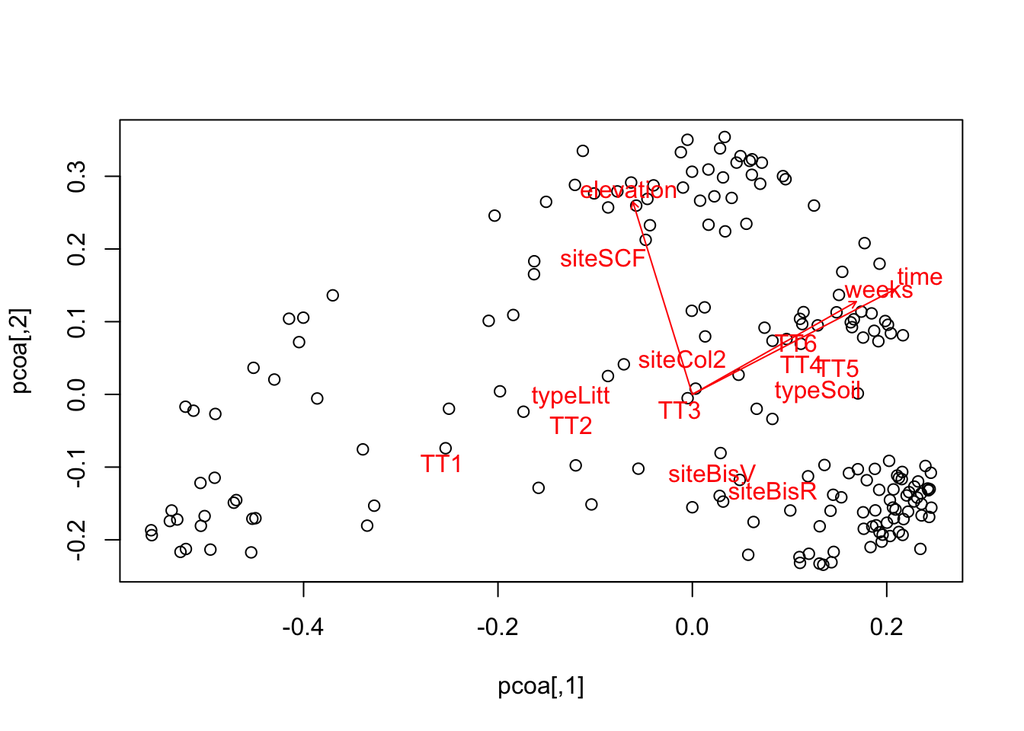

```r
plot(pcoa)
plot(fit2, p.max=0.1, col="red")
```